**Research question:** *Does dose or route predict whether a 7,8-DHF user reports a side effect — and if not, what does?*

# 7,8-DHF: Dose, Route and Side-Effect Reporting

## Abstract

Pipeline B records the dose and route a patient states; Pipeline A records whether they named a side effect. They share an author key, so the two can be joined.

**Scope is 7,8-DHF alone.** 4′-DMA is excluded, not reported alongside: milligrams do not pool across compounds differing about tenfold in potency, and at 15 dosed users it cannot support an inference of its own.

Across **116 analysable users**, 49 state a dose and 45 a route. Neither predicts side-effect reporting — every dose band's interval contains the 36.2% cohort baseline, the trend across bands is flat (p = 0.49), and sublingual does not separate from other routes (p = 0.53).

**The more useful result is what does predict it.** Two things, and both are artifacts of how the data was made rather than facts about the drug:

1. Saying the compound *worsened* something — which is not a predictor at all. All 16 users who said so also have a side effect recorded, so the term is not even estimable. Pipeline B's `worsened: insomnia` and Pipeline A's `side_effects: ["insomnia"]` are the same sentence read twice.
2. How much the person wrote about the compound. And the increase is *smaller* than independent accumulation across reports would predict, so there is no evidence of anything beyond more-text-more-chances.

Nothing pharmacological survives. A side-effect rate computed this way measures reporting intensity, not risk — which constrains how any drug in this panel can be compared.

The reported profile itself is dominated by sleep and activation, each affecting about one user in ten.

## 1. Cohort and provenance

| quantity | source |
| --- | --- |
| dose, route | Pipeline B — `pipeline_b_compound_exposures`, plus the 2026-09-01 repair |
| side-effect presence | Pipeline A — `treatment_reports.side_effects` in `comparators.db` |
| join key | `author_hash` = `user_id` |

`comparators.db` keeps 7,8-DHF as its own `drug_id`, so side effects attribute to this compound rather than the tropoflavin family.

**The outcome is a reporting rate, not incidence.** It means "this user named a side effect somewhere in their posts". A user is analysable only if they filed a sentiment report for the compound — without one there is no outcome to score, and treating their silence as "no side effect" would invent data.

```
7,8-DHF analysable users : 116
  with a stated dose     : 49
  with a stated route    : 45
  recovered by the repair: 20

BASELINE: 42/116 = 36.2%  [28.0%, 45.3%]
```

## 2. Dose

The dot is the point estimate, the bar the 95% Wilson interval, the dashed line the cohort baseline. Wilson rather than the normal approximation because most cells hold fewer than fifteen people.

```
band                n  >=1 SE    rate   95% CI
<5 mg               2       1   50.0%   [   9%,   91%]
5 to <10 mg         2       1   50.0%   [   9%,   91%]
10 to <25 mg        7       1   14.3%   [   3%,   51%]
25 to <50 mg       16       7   43.8%   [  23%,   67%]
50 to <100 mg       8       4   50.0%   [  22%,   78%]
>=100 mg            6       3   50.0%   [  19%,   81%]
multiple bands      7       4   57.1%   [  25%,   84%]
```

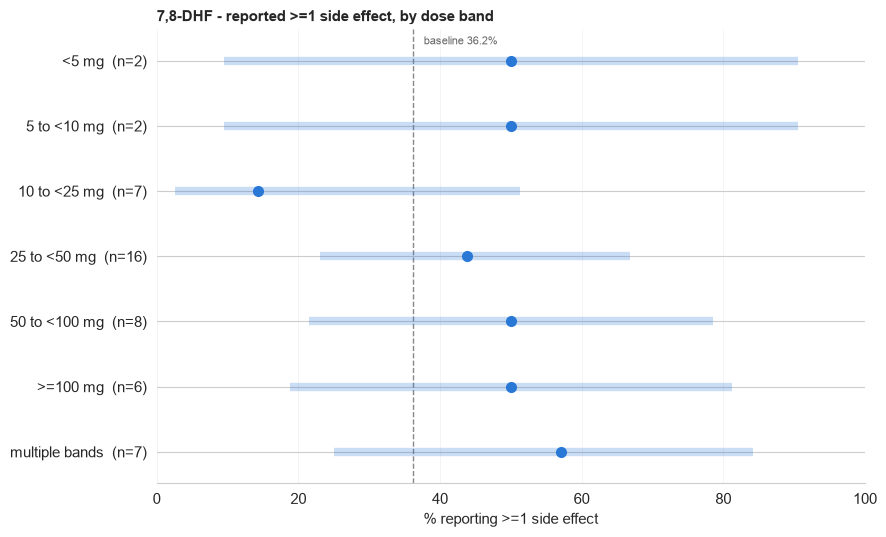

```
trend across 6 bands (n=41): z = +0.70, p = 0.487
<25 mg vs >=25 mg: 3/11 vs 14/30, Fisher exact p = 0.309
```

## 3. Route

Sublingual (`oral mucosal`) dominates, so the contrast is sublingual against every other stated route.

Read the small cells carefully. `swallowed oral` and `nasal mucosal` each contain a single user who reported a side effect; one more would move `swallowed oral` from 14% to 29%. Any apparent route effect here is a small-denominator illusion, not a signal.

```
route                         n  >=1 SE    rate   95% CI
oral mucosal                 26      10   38.5%   [  22%,   57%]
swallowed oral                7       1   14.3%   [   3%,   51%]
nasal mucosal                 5       1   20.0%   [   4%,   62%]
dermal                        1       0    0.0%   [   0%,   79%]
rectal or vaginal             1       0    0.0%   [   0%,   79%]
multiple route families       5       3   60.0%   [  23%,   88%]
(no route stated)            71      27   38.0%

sublingual 10/26 vs other routes 5/19  ->  Fisher exact p = 0.526
```

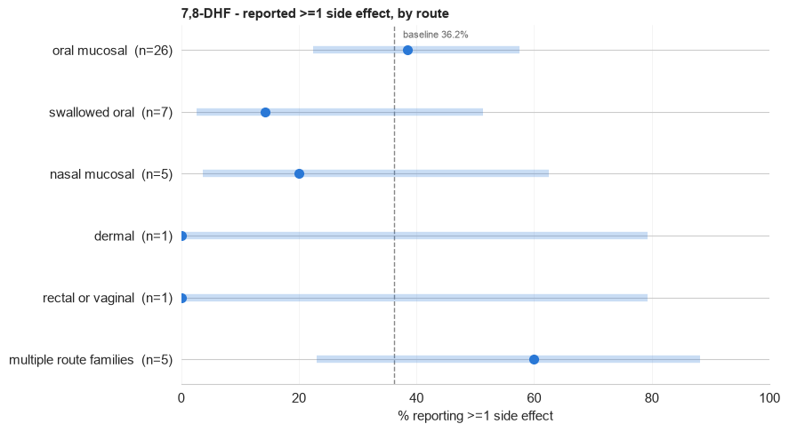

### Is there a route-specific local effect?

```
terms matching mucosal language: 1
   1x red burning hives on face and arms

('irritability' matches the pattern on 'irrit' but is mood, not mucosa -
 which is why this is inspected rather than counted automatically.)
```

## 4. What users actually report

Raw strings are uncanonicalised in `comparators.db` — `headache` and `headaches` are separate entries — so presence/absence per person is safe but any profile needs grouping first. `D.canon_side_effect` does that; terms it cannot place are reported rather than swept into an "other" bucket.

The denominator is the whole cohort, so these read as "x% of 7,8-DHF users mentioned this", not "x% of side effects were this".

```
category                    users  % of cohort   95% CI
```

```
sleep / wakefulness            11         9.5%   [ 5.4%, 16.2%]
activation / anxiety           11         9.5%   [ 5.4%, 16.2%]
headache                       10         8.6%   [ 4.7%, 15.1%]
cognitive / perceptual          6         5.2%   [ 2.4%, 10.8%]
mood / motivation               6         5.2%   [ 2.4%, 10.8%]
hair / skin                     5         4.3%   [ 1.9%,  9.7%]
appetite / GI                   4         3.4%   [ 1.3%,  8.5%]
cardiovascular                  2         1.7%   [ 0.5%,  6.1%]
tolerance / duration            2         1.7%   [ 0.5%,  6.1%]
fatigue / sedation              2         1.7%   [ 0.5%,  6.1%]
vision                          1         0.9%   [ 0.2%,  4.7%]
sexual                          1         0.9%   [ 0.2%,  4.7%]

unmapped: 33 mentions, 32 distinct terms
  e.g. ['stopped working', 'remembering specific events', 'feeling horror and despair', 'shadowy doubling effects on thoughts', 'synaptic plasticity too high', 'bad nootropic trip']
```

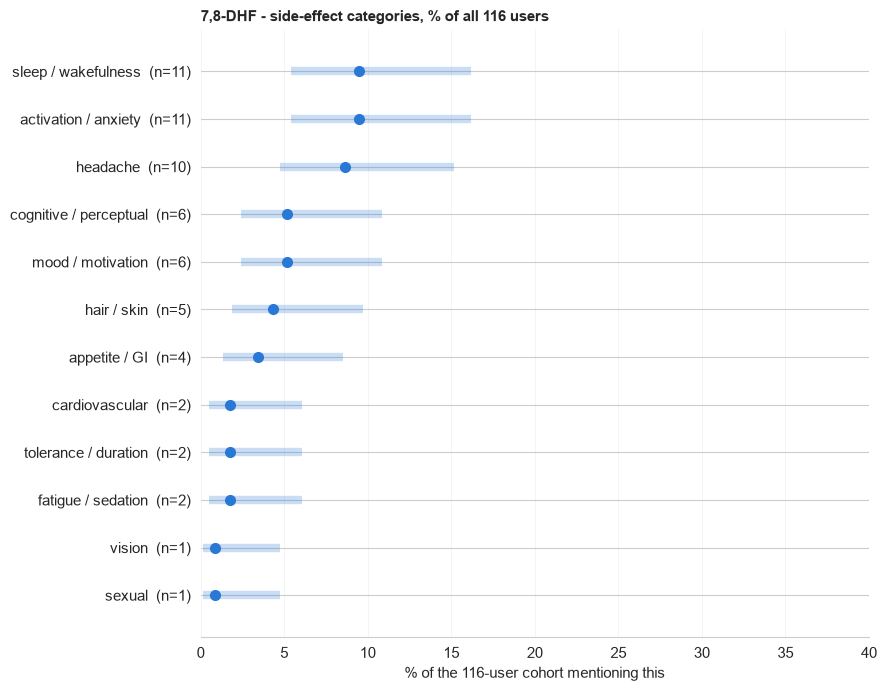

## 5. What predicts reporting a side effect

Since dose and route do not, the question is what does. The first candidate has to be removed before any model is fit, and removing it is the more interesting result.

### `worsened` is the same variable, not a predictor

Pipeline B writes `7,8-dhf: worsened: insomnia`. Pipeline A writes `side_effects: ["insomnia"]`. These are two extractions of **the same sentence**.

The cross-tabulation makes it unarguable: every user who said the compound worsened something also has a side effect recorded. Not a strong association — a perfect one. Logistic regression cannot estimate a coefficient under complete separation, which is the statistical way of saying the two columns carry the same information.

```
                        no side effect   side effect
  did not                           74            26
  said 'worsened'                    0            16

16 of 16 who said it worsened something also named a side effect (100%)
complete separation -- the term is not estimable and is excluded below.
```

```
'worsened: X' rows carrying a symptom : 31
   X is literally a side-effect string : 20
   no overlap                          : 11   <- Pipeline A found nothing
   MATCH  'overthinking'               -> ['analysis paralysis by overthinking', 'irritability', 'lightheadedness']
   MATCH  'restlessness'               -> ['analysis paralysis by overthinking', 'irritability', 'lightheadedness']
   MATCH  'anxiety'                    -> ['anxiety', 'depression']
   MATCH  'heart palpitations'         -> ['chest tightness', 'heart palpitations']
   MATCH  'chest tightness'            -> ['chest tightness', 'heart palpitations']
   differ 'reflux'                     -> []
```

### The model, with that term excluded

What remains is volume, stack size, and whether a dose was stated.

```
n = 116   pseudo R2 = 0.062
  term            odds ratio              95% CI        p
  log_reports           3.30        [1.17, 9.32]    0.024 *
  log_texts             0.83        [0.50, 1.39]    0.482
  stack                 1.01        [0.96, 1.07]    0.660
  has_dose              1.47        [0.66, 3.30]    0.344

A pseudo R2 near 0.05 means these four together explain very little.
```

### And the volume term is close to arithmetic

If naming a side effect is roughly an independent chance per report, someone with four reports has four chances. Estimating that per-report chance from the single-report users and projecting it forward shows the observed rise is *slower* than pure accumulation — so there is no evidence of anything beyond more text, more opportunities.

```
per-report chance, from the 45 single-report users: q = 0.267

  group           users  mean reports  observed  if chance
  1 report           45           1.0     26.7%      26.7%
  2-3 reports        42           2.3     31.0%      51.1%
  4+ reports         29           6.9     58.6%      88.1%
```

## 6. Is 49 dosed users really all there is?

That count comes from the extraction, which is known to under-report (issue #143), so it is worth checking against the raw text. Scanning the same 752 author histories for a mass quantity near a compound mention:

| filter | authors |
| --- | --- |
| any dose within 120 chars of a mention | 146 |
| after dropping `mg/kg` and study citations | 135 |
| after dropping doses nearer *another* drug name | 92 |
| after requiring first-person use language | 45 |
| **what Pipeline B extracted** (both compounds) | **59** |

**The true count is likely 60–75.** More extraction effort adds perhaps ten or fifteen people. It does not change the shape: 747 of 752 authors mention this compound and about a twelfth ever write down a number. The doses were never recorded, so they cannot be recovered. Reproduce with `raw_dose_count.py` and `raw_dose_strict.py`.

## 7. What constrains this

**1. The outcome measures reporting, not incidence.** Section 5 is the evidence: what predicts it is how much someone wrote, plus a circular term. Someone who tolerated the compound and someone who never discussed side effects are indistinguishable.

**2. Underpowered by construction.** The largest dose band holds 16 users. A true difference of ten or fifteen points between bands would not reliably surface. A flat result is *absence of evidence*, not evidence of absence.

**3. Dose and route are rarely co-reported**, so no interaction is estimable.

**4. Recovered rows are ~85–90% precise.** The corroboration filter removes the three dose misattributions it can detect. Routes are weaker — of 20 recovered route values, 4 were unsupported by route language near the compound. Lean on route less than dose.

**5. Self-selection.** Someone harmed has more reason to post, and to say what they took. Nothing here corrects for that, and it acts in the same direction as the volume artifact.

**6. Category boundaries are ours.** `D.SE_CATEGORIES` is a regex map, not a validated ontology; `activation / anxiety` and `sleep / wakefulness` plausibly overlap in the underlying complaint.

**These findings reflect reporting patterns in an online community, not population-level treatment effects. This is not medical advice.**